# Risk Factor Analysis

## Outcome Variable

**Outcome Variable:** y_rate_len

## Predictor Variables

**Intervention Variable:** nchldlt5

**Adjustment Set:**

- arm
- W_mage
- meducyrs
- feducyrs
- hhwealth_quart
- hfoodsec
- W_mhtcm
- W_mwtkg
- W_mbmi
- W_nrooms
- W_parity
- impfloor
- impsan
- safeh20
- delta_W_mage
- delta_meducyrs
- delta_feducyrs
- delta_hhwealth_quart
- delta_hfoodsec
- delta_W_mhtcm
- delta_W_mwtkg
- delta_W_mbmi
- delta_W_nrooms
- delta_W_parity
- delta_impfloor
- delta_impsan
- delta_safeh20

## Stratifying Variables

The analysis was stratified on these variable(s):

- agecat
- studyid
- country

## Data Summary

| agecat | studyid | country | nchldlt5 | n_cell | n | outcome_variable |
| --- | --- | --- | --- | --- | --- | --- |
| 0-3 months | ki1000108-IRC | INDIA | 1 | 82 | 377 | y_rate_len |
| 0-3 months | ki1000108-IRC | INDIA | 2+ | 295 | 377 | y_rate_len |
| 0-3 months | ki1017093b-PROVIDE | BANGLADESH | 1 | 471 | 640 | y_rate_len |
| 0-3 months | ki1017093b-PROVIDE | BANGLADESH | 2+ | 169 | 640 | y_rate_len |
| 0-3 months | ki1017093c-NIH-Crypto | BANGLADESH | 1 | 512 | 721 | y_rate_len |
| 0-3 months | ki1017093c-NIH-Crypto | BANGLADESH | 2+ | 209 | 721 | y_rate_len |
| 0-3 months | kiGH5241-JiVitA-3 | BANGLADESH | 1 | 12371 | 19861 | y_rate_len |
| 0-3 months | kiGH5241-JiVitA-3 | BANGLADESH | 2+ | 7490 | 19861 | y_rate_len |
| 3-6 months | ki1000108-IRC | INDIA | 1 | 87 | 397 | y_rate_len |
| 3-6 months | ki1000108-IRC | INDIA | 2+ | 310 | 397 | y_rate_len |
| 3-6 months | ki1017093b-PROVIDE | BANGLADESH | 1 | 434 | 598 | y_rate_len |
| 3-6 months | ki1017093b-PROVIDE | BANGLADESH | 2+ | 164 | 598 | y_rate_len |
| 3-6 months | ki1017093c-NIH-Crypto | BANGLADESH | 1 | 492 | 695 | y_rate_len |
| 3-6 months | ki1017093c-NIH-Crypto | BANGLADESH | 2+ | 203 | 695 | y_rate_len |
| 3-6 months | ki1066203-TanzaniaChild2 | TANZANIA, UNITED REPUBLIC OF | 1 | 1146 | 1656 | y_rate_len |
| 3-6 months | ki1066203-TanzaniaChild2 | TANZANIA, UNITED REPUBLIC OF | 2+ | 510 | 1656 | y_rate_len |
| 3-6 months | kiGH5241-JiVitA-3 | BANGLADESH | 1 | 8103 | 12572 | y_rate_len |
| 3-6 months | kiGH5241-JiVitA-3 | BANGLADESH | 2+ | 4469 | 12572 | y_rate_len |
| 6-9 months | ki1000108-IRC | INDIA | 1 | 89 | 407 | y_rate_len |
| 6-9 months | ki1000108-IRC | INDIA | 2+ | 318 | 407 | y_rate_len |
| 6-9 months | ki1017093b-PROVIDE | BANGLADESH | 1 | 410 | 565 | y_rate_len |
| 6-9 months | ki1017093b-PROVIDE | BANGLADESH | 2+ | 155 | 565 | y_rate_len |
| 6-9 months | ki1017093c-NIH-Crypto | BANGLADESH | 1 | 488 | 688 | y_rate_len |
| 6-9 months | ki1017093c-NIH-Crypto | BANGLADESH | 2+ | 200 | 688 | y_rate_len |
| 6-9 months | ki1066203-TanzaniaChild2 | TANZANIA, UNITED REPUBLIC OF | 1 | 1036 | 1480 | y_rate_len |
| 6-9 months | ki1066203-TanzaniaChild2 | TANZANIA, UNITED REPUBLIC OF | 2+ | 444 | 1480 | y_rate_len |
| 6-9 months | ki1148112-LCNI-5 | MALAWI | 1 | 261 | 557 | y_rate_len |
| 6-9 months | ki1148112-LCNI-5 | MALAWI | 2+ | 296 | 557 | y_rate_len |
| 9-12 months | ki1000108-IRC | INDIA | 1 | 88 | 400 | y_rate_len |
| 9-12 months | ki1000108-IRC | INDIA | 2+ | 312 | 400 | y_rate_len |

[output cut: 52 more lines]

The following strata were considered:

- agecat: 0-3 months, studyid: ki1000108-IRC, country: INDIA
- agecat: 0-3 months, studyid: ki1017093b-PROVIDE, country: BANGLADESH
- agecat: 0-3 months, studyid: ki1017093c-NIH-Crypto, country: BANGLADESH
- agecat: 0-3 months, studyid: kiGH5241-JiVitA-3, country: BANGLADESH
- agecat: 12-15 months, studyid: ki1000108-IRC, country: INDIA
- agecat: 12-15 months, studyid: ki1017093b-PROVIDE, country: BANGLADESH
- agecat: 12-15 months, studyid: ki1017093c-NIH-Crypto, country: BANGLADESH
- agecat: 12-15 months, studyid: ki1066203-TanzaniaChild2, country: TANZANIA, UNITED REPUBLIC OF
- agecat: 12-15 months, studyid: ki1112895-iLiNS-Zinc, country: BURKINA FASO
- agecat: 12-15 months, studyid: ki1148112-LCNI-5, country: MALAWI
- agecat: 15-18 months, studyid: ki1000108-IRC, country: INDIA
- agecat: 15-18 months, studyid: ki1017093b-PROVIDE, country: BANGLADESH
- agecat: 15-18 months, studyid: ki1017093c-NIH-Crypto, country: BANGLADESH
- agecat: 15-18 months, studyid: ki1066203-TanzaniaChild2, country: TANZANIA, UNITED REPUBLIC OF
- agecat: 15-18 months, studyid: ki1112895-iLiNS-Zinc, country: BURKINA FASO
- agecat: 15-18 months, studyid: ki1148112-LCNI-5, country: MALAWI
- agecat: 18-21 months, studyid: ki1000108-IRC, country: INDIA
- agecat: 18-21 months, studyid: ki1017093b-PROVIDE, country: BANGLADESH
- agecat: 18-21 months, studyid: ki1017093c-NIH-Crypto, country: BANGLADESH
- agecat: 18-21 months, studyid: ki1066203-TanzaniaChild2, country: TANZANIA, UNITED REPUBLIC OF
- agecat: 18-21 months, studyid: ki1148112-LCNI-5, country: MALAWI
- agecat: 21-24 months, studyid: ki1000108-IRC, country: INDIA
- agecat: 21-24 months, studyid: ki1017093b-PROVIDE, country: BANGLADESH
- agecat: 21-24 months, studyid: ki1017093c-NIH-Crypto, country: BANGLADESH
- agecat: 21-24 months, studyid: ki1148112-LCNI-5, country: MALAWI
- agecat: 3-6 months, studyid: ki1000108-IRC, country: INDIA
- agecat: 3-6 months, studyid: ki1017093b-PROVIDE, country: BANGLADESH
- agecat: 3-6 months, studyid: ki1017093c-NIH-Crypto, country: BANGLADESH
- agecat: 3-6 months, studyid: ki1066203-TanzaniaChild2, country: TANZANIA, UNITED REPUBLIC OF
- agecat: 3-6 months, studyid: kiGH5241-JiVitA-3, country: BANGLADESH
- agecat: 6-9 months, studyid: ki1000108-IRC, country: INDIA
- agecat: 6-9 months, studyid: ki1017093b-PROVIDE, country: BANGLADESH
- agecat: 6-9 months, studyid: ki1017093c-NIH-Crypto, country: BANGLADESH
- agecat: 6-9 months, studyid: ki1066203-TanzaniaChild2, country: TANZANIA, UNITED REPUBLIC OF
- agecat: 6-9 months, studyid: ki1148112-LCNI-5, country: MALAWI
- agecat: 9-12 months, studyid: ki1000108-IRC, country: INDIA
- agecat: 9-12 months, studyid: ki1017093b-PROVIDE, country: BANGLADESH
- agecat: 9-12 months, studyid: ki1017093c-NIH-Crypto, country: BANGLADESH
- agecat: 9-12 months, studyid: ki1066203-TanzaniaChild2, country: TANZANIA, UNITED REPUBLIC OF
- agecat: 9-12 months, studyid: ki1112895-iLiNS-Zinc, country: BURKINA FASO
- agecat: 9-12 months, studyid: ki1148112-LCNI-5, country: MALAWI

### Dropped Strata

Some strata were dropped due to rare outcomes:

- agecat: 18-21 months, studyid: ki1066203-TanzaniaChild2, country: TANZANIA, UNITED REPUBLIC OF

## Methods Detail

We’re interested in the causal parameters $E[Y_a]$ for all values of $a \in \mathcal{A}$. These parameters represent the mean outcome if, possibly contrary to fact, we intervened to set all units to have $A=a$. Under the randomization and positivity assumptions, these are identified by the statistical parameters $\psi_a=E_W[E_{Y|A,W}(Y|A=a,W)]$. In addition, we’re interested in the mean of $Y$, $E[Y]$ under no intervention (the observed mean). We will estimate these parameters by using SuperLearner to fit the relevant likelihood factors – $E_{Y|A,W}(Y|A=a,W)$ and $p(A=a|W)$, and then updating our likelihood fit using a joint TMLE.

For unadjusted analyses ($W=\{\}$), initial likelihoods were estimated using Lrnr_glm to estimate the simple $E(Y|A)$ and Lrnr_mean to estimate $p(A)$. For adjusted analyses, a small library containing Lrnr_glmnet, Lrnr_xgboost, and Lrnr_mean was used.

# Results Detail

## Results Plots

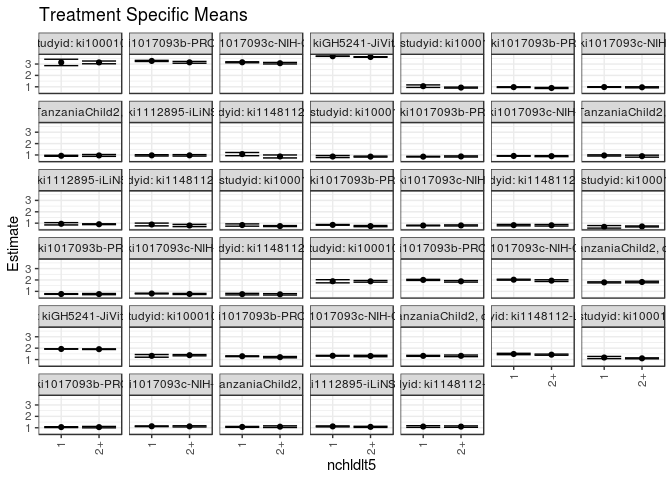

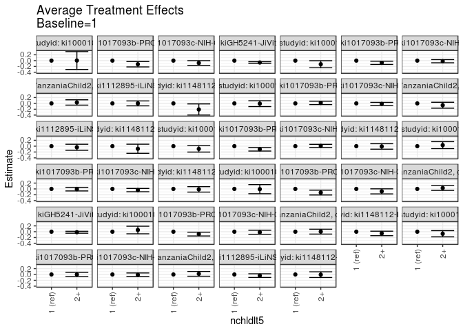

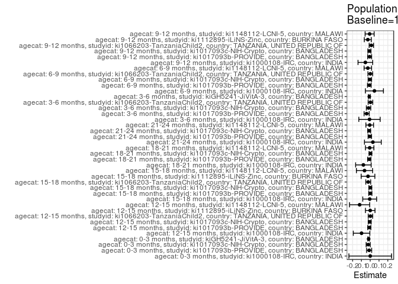

## Results Table

### Parameter: TSM

| agecat | studyid | country | intervention_level | baseline_level | estimate | ci_lower | ci_upper |
| --- | --- | --- | --- | --- | --- | --- | --- |
| 0-3 months | ki1000108-IRC | INDIA | 1 | NA | 3.1380251 | 2.8573273 | 3.4187228 |
| 0-3 months | ki1000108-IRC | INDIA | 2+ | NA | 3.1412147 | 3.0214614 | 3.2609680 |
| 0-3 months | ki1017093b-PROVIDE | BANGLADESH | 1 | NA | 3.2696798 | 3.2213786 | 3.3179810 |
| 0-3 months | ki1017093b-PROVIDE | BANGLADESH | 2+ | NA | 3.1465891 | 3.0677013 | 3.2254769 |
| 0-3 months | ki1017093c-NIH-Crypto | BANGLADESH | 1 | NA | 3.1520616 | 3.1080045 | 3.1961187 |
| 0-3 months | ki1017093c-NIH-Crypto | BANGLADESH | 2+ | NA | 3.0701267 | 3.0027653 | 3.1374881 |
| 0-3 months | kiGH5241-JiVitA-3 | BANGLADESH | 1 | NA | 3.6827765 | 3.6694094 | 3.6961436 |
| 0-3 months | kiGH5241-JiVitA-3 | BANGLADESH | 2+ | NA | 3.6182339 | 3.5927233 | 3.6437445 |
| 3-6 months | ki1000108-IRC | INDIA | 1 | NA | 1.8886824 | 1.7511137 | 2.0262511 |
| 3-6 months | ki1000108-IRC | INDIA | 2+ | NA | 1.8809603 | 1.8085603 | 1.9533603 |
| 3-6 months | ki1017093b-PROVIDE | BANGLADESH | 1 | NA | 2.0065646 | 1.9601690 | 2.0529602 |
| 3-6 months | ki1017093b-PROVIDE | BANGLADESH | 2+ | NA | 1.8824174 | 1.8144677 | 1.9503671 |
| 3-6 months | ki1017093c-NIH-Crypto | BANGLADESH | 1 | NA | 2.0244814 | 1.9820049 | 2.0669579 |
| 3-6 months | ki1017093c-NIH-Crypto | BANGLADESH | 2+ | NA | 1.9409282 | 1.8651143 | 2.0167420 |
| 3-6 months | ki1066203-TanzaniaChild2 | TANZANIA, UNITED REPUBLIC OF | 1 | NA | 1.7905408 | 1.7447800 | 1.8363016 |
| 3-6 months | ki1066203-TanzaniaChild2 | TANZANIA, UNITED REPUBLIC OF | 2+ | NA | 1.8223342 | 1.7542631 | 1.8904052 |
| 3-6 months | kiGH5241-JiVitA-3 | BANGLADESH | 1 | NA | 1.9305504 | 1.9156947 | 1.9454060 |
| 3-6 months | kiGH5241-JiVitA-3 | BANGLADESH | 2+ | NA | 1.9125320 | 1.8822167 | 1.9428473 |
| 6-9 months | ki1000108-IRC | INDIA | 1 | NA | 1.3246551 | 1.2074646 | 1.4418456 |
| 6-9 months | ki1000108-IRC | INDIA | 2+ | NA | 1.3829091 | 1.3277378 | 1.4380805 |
| 6-9 months | ki1017093b-PROVIDE | BANGLADESH | 1 | NA | 1.2924967 | 1.2590021 | 1.3259912 |
| 6-9 months | ki1017093b-PROVIDE | BANGLADESH | 2+ | NA | 1.2110417 | 1.1556340 | 1.2664493 |
| 6-9 months | ki1017093c-NIH-Crypto | BANGLADESH | 1 | NA | 1.3323655 | 1.2985244 | 1.3662066 |
| 6-9 months | ki1017093c-NIH-Crypto | BANGLADESH | 2+ | NA | 1.3133010 | 1.2537716 | 1.3728303 |
| 6-9 months | ki1066203-TanzaniaChild2 | TANZANIA, UNITED REPUBLIC OF | 1 | NA | 1.3237691 | 1.2789273 | 1.3686108 |
| 6-9 months | ki1066203-TanzaniaChild2 | TANZANIA, UNITED REPUBLIC OF | 2+ | NA | 1.3263126 | 1.2568106 | 1.3958146 |
| 6-9 months | ki1148112-LCNI-5 | MALAWI | 1 | NA | 1.4887292 | 1.4298651 | 1.5475934 |
| 6-9 months | ki1148112-LCNI-5 | MALAWI | 2+ | NA | 1.4299280 | 1.3804845 | 1.4793714 |
| 9-12 months | ki1000108-IRC | INDIA | 1 | NA | 1.1786201 | 1.0808940 | 1.2763462 |
| 9-12 months | ki1000108-IRC | INDIA | 2+ | NA | 1.1087675 | 1.0664436 | 1.1510914 |
| 9-12 months | ki1017093b-PROVIDE | BANGLADESH | 1 | NA | 1.0565496 | 1.0196493 | 1.0934499 |
| 9-12 months | ki1017093b-PROVIDE | BANGLADESH | 2+ | NA | 1.0561576 | 0.9946927 | 1.1176225 |
| 9-12 months | ki1017093c-NIH-Crypto | BANGLADESH | 1 | NA | 1.1324624 | 1.1008161 | 1.1641087 |
| 9-12 months | ki1017093c-NIH-Crypto | BANGLADESH | 2+ | NA | 1.1223317 | 1.0701208 | 1.1745427 |
| 9-12 months | ki1066203-TanzaniaChild2 | TANZANIA, UNITED REPUBLIC OF | 1 | NA | 1.0726968 | 1.0327734 | 1.1126203 |
| 9-12 months | ki1066203-TanzaniaChild2 | TANZANIA, UNITED REPUBLIC OF | 2+ | NA | 1.0947628 | 1.0234635 | 1.1660622 |
| 9-12 months | ki1112895-iLiNS-Zinc | BURKINA FASO | 1 | NA | 1.1189099 | 1.0784738 | 1.1593460 |
| 9-12 months | ki1112895-iLiNS-Zinc | BURKINA FASO | 2+ | NA | 1.0790443 | 1.0296924 | 1.1283962 |
| 9-12 months | ki1148112-LCNI-5 | MALAWI | 1 | NA | 1.1076323 | 1.0342406 | 1.1810240 |
| 9-12 months | ki1148112-LCNI-5 | MALAWI | 2+ | NA | 1.1008193 | 1.0386294 | 1.1630092 |
| 12-15 months | ki1000108-IRC | INDIA | 1 | NA | 1.0538685 | 0.9418515 | 1.1658856 |
| 12-15 months | ki1000108-IRC | INDIA | 2+ | NA | 0.9301289 | 0.8875784 | 0.9726794 |
| 12-15 months | ki1017093b-PROVIDE | BANGLADESH | 1 | NA | 0.9702811 | 0.9378366 | 1.0027256 |
| 12-15 months | ki1017093b-PROVIDE | BANGLADESH | 2+ | NA | 0.8953448 | 0.8508740 | 0.9398156 |
| 12-15 months | ki1017093c-NIH-Crypto | BANGLADESH | 1 | NA | 0.9767586 | 0.9476001 | 1.0059171 |
| 12-15 months | ki1017093c-NIH-Crypto | BANGLADESH | 2+ | NA | 0.9567091 | 0.9104981 | 1.0029201 |
| 12-15 months | ki1066203-TanzaniaChild2 | TANZANIA, UNITED REPUBLIC OF | 1 | NA | 0.9290732 | 0.8850031 | 0.9731432 |
| 12-15 months | ki1066203-TanzaniaChild2 | TANZANIA, UNITED REPUBLIC OF | 2+ | NA | 0.9606862 | 0.8812072 | 1.0401653 |
| 12-15 months | ki1112895-iLiNS-Zinc | BURKINA FASO | 1 | NA | 0.9670163 | 0.9109435 | 1.0230892 |
| 12-15 months | ki1112895-iLiNS-Zinc | BURKINA FASO | 2+ | NA | 0.9668309 | 0.9043048 | 1.0293570 |
| 12-15 months | ki1148112-LCNI-5 | MALAWI | 1 | NA | 1.0790960 | 0.9387775 | 1.2194145 |
| 12-15 months | ki1148112-LCNI-5 | MALAWI | 2+ | NA | 0.8704460 | 0.7412122 | 0.9996797 |
| 15-18 months | ki1000108-IRC | INDIA | 1 | NA | 0.8649712 | 0.7756113 | 0.9543311 |
| 15-18 months | ki1000108-IRC | INDIA | 2+ | NA | 0.8559017 | 0.8124444 | 0.8993591 |
| 15-18 months | ki1017093b-PROVIDE | BANGLADESH | 1 | NA | 0.8549411 | 0.8237296 | 0.8861526 |
| 15-18 months | ki1017093b-PROVIDE | BANGLADESH | 2+ | NA | 0.8722626 | 0.8237737 | 0.9207516 |
| 15-18 months | ki1017093c-NIH-Crypto | BANGLADESH | 1 | NA | 0.9165949 | 0.8886549 | 0.9445350 |
| 15-18 months | ki1017093c-NIH-Crypto | BANGLADESH | 2+ | NA | 0.8989775 | 0.8548437 | 0.9431113 |
| 15-18 months | ki1066203-TanzaniaChild2 | TANZANIA, UNITED REPUBLIC OF | 1 | NA | 0.9596792 | 0.9085185 | 1.0108399 |
| 15-18 months | ki1066203-TanzaniaChild2 | TANZANIA, UNITED REPUBLIC OF | 2+ | NA | 0.8974048 | 0.8094399 | 0.9853697 |
| 15-18 months | ki1112895-iLiNS-Zinc | BURKINA FASO | 1 | NA | 0.9457035 | 0.8450874 | 1.0463195 |
| 15-18 months | ki1112895-iLiNS-Zinc | BURKINA FASO | 2+ | NA | 0.9075310 | 0.8706437 | 0.9444184 |
| 15-18 months | ki1148112-LCNI-5 | MALAWI | 1 | NA | 0.8848665 | 0.7637164 | 1.0060165 |
| 15-18 months | ki1148112-LCNI-5 | MALAWI | 2+ | NA | 0.7965068 | 0.6995913 | 0.8934223 |
| 18-21 months | ki1000108-IRC | INDIA | 1 | NA | 0.8373107 | 0.7367035 | 0.9379178 |
| 18-21 months | ki1000108-IRC | INDIA | 2+ | NA | 0.7442617 | 0.7019877 | 0.7865356 |
| 18-21 months | ki1017093b-PROVIDE | BANGLADESH | 1 | NA | 0.8500641 | 0.8183793 | 0.8817490 |
| 18-21 months | ki1017093b-PROVIDE | BANGLADESH | 2+ | NA | 0.7433433 | 0.6925469 | 0.7941396 |
| 18-21 months | ki1017093c-NIH-Crypto | BANGLADESH | 1 | NA | 0.7952447 | 0.7677047 | 0.8227847 |
| 18-21 months | ki1017093c-NIH-Crypto | BANGLADESH | 2+ | NA | 0.8030008 | 0.7555385 | 0.8504632 |
| 18-21 months | ki1148112-LCNI-5 | MALAWI | 1 | NA | 0.8269403 | 0.7659034 | 0.8879772 |
| 18-21 months | ki1148112-LCNI-5 | MALAWI | 2+ | NA | 0.8171380 | 0.7492849 | 0.8849910 |
| 21-24 months | ki1000108-IRC | INDIA | 1 | NA | 0.6783122 | 0.5674006 | 0.7892239 |
| 21-24 months | ki1000108-IRC | INDIA | 2+ | NA | 0.7133086 | 0.6697287 | 0.7568885 |
| 21-24 months | ki1017093b-PROVIDE | BANGLADESH | 1 | NA | 0.7675609 | 0.7356526 | 0.7994692 |
| 21-24 months | ki1017093b-PROVIDE | BANGLADESH | 2+ | NA | 0.7603843 | 0.7069736 | 0.8137950 |
| 21-24 months | ki1017093c-NIH-Crypto | BANGLADESH | 1 | NA | 0.8111836 | 0.7815063 | 0.8408608 |
| 21-24 months | ki1017093c-NIH-Crypto | BANGLADESH | 2+ | NA | 0.7718455 | 0.7244719 | 0.8192191 |
| 21-24 months | ki1148112-LCNI-5 | MALAWI | 1 | NA | 0.7558214 | 0.6882060 | 0.8234367 |
| 21-24 months | ki1148112-LCNI-5 | MALAWI | 2+ | NA | 0.7408407 | 0.6785598 | 0.8031215 |

### Parameter: E(Y)

| agecat | studyid | country | intervention_level | baseline_level | estimate | ci_lower | ci_upper |
| --- | --- | --- | --- | --- | --- | --- | --- |
| 0-3 months | ki1000108-IRC | INDIA | NA | NA | 3.1382493 | 3.0275242 | 3.2489743 |
| 0-3 months | ki1017093b-PROVIDE | BANGLADESH | NA | NA | 3.2576810 | 3.2206777 | 3.2946843 |
| 0-3 months | ki1017093c-NIH-Crypto | BANGLADESH | NA | NA | 3.1292449 | 3.0928504 | 3.1656393 |
| 0-3 months | kiGH5241-JiVitA-3 | BANGLADESH | NA | NA | 3.6645460 | 3.6543084 | 3.6747835 |
| 3-6 months | ki1000108-IRC | INDIA | NA | NA | 1.8806738 | 1.8168757 | 1.9444719 |
| 3-6 months | ki1017093b-PROVIDE | BANGLADESH | NA | NA | 1.9657457 | 1.9318660 | 1.9996254 |
| 3-6 months | ki1017093c-NIH-Crypto | BANGLADESH | NA | NA | 2.0057973 | 1.9693775 | 2.0422170 |
| 3-6 months | ki1066203-TanzaniaChild2 | TANZANIA, UNITED REPUBLIC OF | NA | NA | 1.7933135 | 1.7575160 | 1.8291109 |
| 3-6 months | kiGH5241-JiVitA-3 | BANGLADESH | NA | NA | 1.9202415 | 1.9097813 | 1.9307016 |
| 6-9 months | ki1000108-IRC | INDIA | NA | NA | 1.3724009 | 1.3237927 | 1.4210091 |
| 6-9 months | ki1017093b-PROVIDE | BANGLADESH | NA | NA | 1.2824185 | 1.2571827 | 1.3076542 |
| 6-9 months | ki1017093c-NIH-Crypto | BANGLADESH | NA | NA | 1.3282695 | 1.2988292 | 1.3577098 |
| 6-9 months | ki1066203-TanzaniaChild2 | TANZANIA, UNITED REPUBLIC OF | NA | NA | 1.3249931 | 1.2883838 | 1.3616025 |
| 6-9 months | ki1148112-LCNI-5 | MALAWI | NA | NA | 1.4616153 | 1.4251800 | 1.4980507 |
| 9-12 months | ki1000108-IRC | INDIA | NA | NA | 1.1234734 | 1.0841051 | 1.1628417 |
| 9-12 months | ki1017093b-PROVIDE | BANGLADESH | NA | NA | 1.0499750 | 1.0230130 | 1.0769370 |
| 9-12 months | ki1017093c-NIH-Crypto | BANGLADESH | NA | NA | 1.1234745 | 1.0972274 | 1.1497215 |
| 9-12 months | ki1066203-TanzaniaChild2 | TANZANIA, UNITED REPUBLIC OF | NA | NA | 1.0855731 | 1.0514671 | 1.1196792 |
| 9-12 months | ki1112895-iLiNS-Zinc | BURKINA FASO | NA | NA | 1.0917213 | 1.0579961 | 1.1254464 |
| 9-12 months | ki1148112-LCNI-5 | MALAWI | NA | NA | 1.1007887 | 1.0539615 | 1.1476158 |
| 12-15 months | ki1000108-IRC | INDIA | NA | NA | 0.9553539 | 0.9137750 | 0.9969329 |
| 12-15 months | ki1017093b-PROVIDE | BANGLADESH | NA | NA | 0.9597501 | 0.9335899 | 0.9859102 |
| 12-15 months | ki1017093c-NIH-Crypto | BANGLADESH | NA | NA | 0.9711395 | 0.9465805 | 0.9956985 |
| 12-15 months | ki1066203-TanzaniaChild2 | TANZANIA, UNITED REPUBLIC OF | NA | NA | 0.9319267 | 0.8950348 | 0.9688186 |
| 12-15 months | ki1112895-iLiNS-Zinc | BURKINA FASO | NA | NA | 0.9671413 | 0.9257414 | 1.0085412 |
| 12-15 months | ki1148112-LCNI-5 | MALAWI | NA | NA | 0.9583944 | 0.8610293 | 1.0557595 |
| 15-18 months | ki1000108-IRC | INDIA | NA | NA | 0.8591216 | 0.8197594 | 0.8984837 |
| 15-18 months | ki1017093b-PROVIDE | BANGLADESH | NA | NA | 0.8560998 | 0.8320145 | 0.8801852 |
| 15-18 months | ki1017093c-NIH-Crypto | BANGLADESH | NA | NA | 0.9177168 | 0.8947657 | 0.9406678 |
| 15-18 months | ki1066203-TanzaniaChild2 | TANZANIA, UNITED REPUBLIC OF | NA | NA | 0.9372014 | 0.8951355 | 0.9792674 |
| 15-18 months | ki1112895-iLiNS-Zinc | BURKINA FASO | NA | NA | 0.9206852 | 0.8832466 | 0.9581239 |
| 15-18 months | ki1148112-LCNI-5 | MALAWI | NA | NA | 0.8198824 | 0.7480865 | 0.8916783 |
| 18-21 months | ki1000108-IRC | INDIA | NA | NA | 0.7598022 | 0.7214752 | 0.7981291 |
| 18-21 months | ki1017093b-PROVIDE | BANGLADESH | NA | NA | 0.8393377 | 0.8153485 | 0.8633269 |
| 18-21 months | ki1017093c-NIH-Crypto | BANGLADESH | NA | NA | 0.7977755 | 0.7744353 | 0.8211158 |
| 18-21 months | ki1148112-LCNI-5 | MALAWI | NA | NA | 0.8206832 | 0.7740479 | 0.8673186 |
| 21-24 months | ki1000108-IRC | INDIA | NA | NA | 0.7084129 | 0.6674749 | 0.7493508 |
| 21-24 months | ki1017093b-PROVIDE | BANGLADESH | NA | NA | 0.7631391 | 0.7377453 | 0.7885328 |
| 21-24 months | ki1017093c-NIH-Crypto | BANGLADESH | NA | NA | 0.7993353 | 0.7748026 | 0.8238681 |
| 21-24 months | ki1148112-LCNI-5 | MALAWI | NA | NA | 0.7500561 | 0.7042548 | 0.7958575 |

### Parameter: ATE

| agecat | studyid | country | intervention_level | baseline_level | estimate | ci_lower | ci_upper |
| --- | --- | --- | --- | --- | --- | --- | --- |
| 0-3 months | ki1000108-IRC | INDIA | 1 | 1 | 0.0000000 | 0.0000000 | 0.0000000 |
| 0-3 months | ki1000108-IRC | INDIA | 2+ | 1 | 0.0031896 | -0.3025422 | 0.3089213 |
| 0-3 months | ki1017093b-PROVIDE | BANGLADESH | 1 | 1 | 0.0000000 | 0.0000000 | 0.0000000 |
| 0-3 months | ki1017093b-PROVIDE | BANGLADESH | 2+ | 1 | -0.1230907 | -0.2157340 | -0.0304474 |
| 0-3 months | ki1017093c-NIH-Crypto | BANGLADESH | 1 | 1 | 0.0000000 | 0.0000000 | 0.0000000 |
| 0-3 months | ki1017093c-NIH-Crypto | BANGLADESH | 2+ | 1 | -0.0819349 | -0.1625703 | -0.0012995 |
| 0-3 months | kiGH5241-JiVitA-3 | BANGLADESH | 1 | 1 | 0.0000000 | 0.0000000 | 0.0000000 |
| 0-3 months | kiGH5241-JiVitA-3 | BANGLADESH | 2+ | 1 | -0.0645426 | -0.0922125 | -0.0368727 |
| 3-6 months | ki1000108-IRC | INDIA | 1 | 1 | 0.0000000 | 0.0000000 | 0.0000000 |
| 3-6 months | ki1000108-IRC | INDIA | 2+ | 1 | -0.0077221 | -0.1640858 | 0.1486416 |
| 3-6 months | ki1017093b-PROVIDE | BANGLADESH | 1 | 1 | 0.0000000 | 0.0000000 | 0.0000000 |
| 3-6 months | ki1017093b-PROVIDE | BANGLADESH | 2+ | 1 | -0.1241473 | -0.2066057 | -0.0416888 |
| 3-6 months | ki1017093c-NIH-Crypto | BANGLADESH | 1 | 1 | 0.0000000 | 0.0000000 | 0.0000000 |
| 3-6 months | ki1017093c-NIH-Crypto | BANGLADESH | 2+ | 1 | -0.0835532 | -0.1704873 | 0.0033808 |
| 3-6 months | ki1066203-TanzaniaChild2 | TANZANIA, UNITED REPUBLIC OF | 1 | 1 | 0.0000000 | 0.0000000 | 0.0000000 |
| 3-6 months | ki1066203-TanzaniaChild2 | TANZANIA, UNITED REPUBLIC OF | 2+ | 1 | 0.0317933 | -0.0503740 | 0.1139606 |
| 3-6 months | kiGH5241-JiVitA-3 | BANGLADESH | 1 | 1 | 0.0000000 | 0.0000000 | 0.0000000 |
| 3-6 months | kiGH5241-JiVitA-3 | BANGLADESH | 2+ | 1 | -0.0180184 | -0.0512947 | 0.0152579 |
| 6-9 months | ki1000108-IRC | INDIA | 1 | 1 | 0.0000000 | 0.0000000 | 0.0000000 |
| 6-9 months | ki1000108-IRC | INDIA | 2+ | 1 | 0.0582540 | -0.0714725 | 0.1879806 |
| 6-9 months | ki1017093b-PROVIDE | BANGLADESH | 1 | 1 | 0.0000000 | 0.0000000 | 0.0000000 |
| 6-9 months | ki1017093b-PROVIDE | BANGLADESH | 2+ | 1 | -0.0814550 | -0.1462854 | -0.0166245 |
| 6-9 months | ki1017093c-NIH-Crypto | BANGLADESH | 1 | 1 | 0.0000000 | 0.0000000 | 0.0000000 |
| 6-9 months | ki1017093c-NIH-Crypto | BANGLADESH | 2+ | 1 | -0.0190645 | -0.0874845 | 0.0493554 |
| 6-9 months | ki1066203-TanzaniaChild2 | TANZANIA, UNITED REPUBLIC OF | 1 | 1 | 0.0000000 | 0.0000000 | 0.0000000 |
| 6-9 months | ki1066203-TanzaniaChild2 | TANZANIA, UNITED REPUBLIC OF | 2+ | 1 | 0.0025435 | -0.0804791 | 0.0855661 |
| 6-9 months | ki1148112-LCNI-5 | MALAWI | 1 | 1 | 0.0000000 | 0.0000000 | 0.0000000 |
| 6-9 months | ki1148112-LCNI-5 | MALAWI | 2+ | 1 | -0.0588013 | -0.1359135 | 0.0183109 |
| 9-12 months | ki1000108-IRC | INDIA | 1 | 1 | 0.0000000 | 0.0000000 | 0.0000000 |
| 9-12 months | ki1000108-IRC | INDIA | 2+ | 1 | -0.0698526 | -0.1759902 | 0.0362851 |
| 9-12 months | ki1017093b-PROVIDE | BANGLADESH | 1 | 1 | 0.0000000 | 0.0000000 | 0.0000000 |
| 9-12 months | ki1017093b-PROVIDE | BANGLADESH | 2+ | 1 | -0.0003920 | -0.0725295 | 0.0717455 |
| 9-12 months | ki1017093c-NIH-Crypto | BANGLADESH | 1 | 1 | 0.0000000 | 0.0000000 | 0.0000000 |
| 9-12 months | ki1017093c-NIH-Crypto | BANGLADESH | 2+ | 1 | -0.0101307 | -0.0715426 | 0.0512813 |
| 9-12 months | ki1066203-TanzaniaChild2 | TANZANIA, UNITED REPUBLIC OF | 1 | 1 | 0.0000000 | 0.0000000 | 0.0000000 |
| 9-12 months | ki1066203-TanzaniaChild2 | TANZANIA, UNITED REPUBLIC OF | 2+ | 1 | 0.0220660 | -0.0596735 | 0.1038055 |
| 9-12 months | ki1112895-iLiNS-Zinc | BURKINA FASO | 1 | 1 | 0.0000000 | 0.0000000 | 0.0000000 |
| 9-12 months | ki1112895-iLiNS-Zinc | BURKINA FASO | 2+ | 1 | -0.0398656 | -0.1028488 | 0.0231175 |
| 9-12 months | ki1148112-LCNI-5 | MALAWI | 1 | 1 | 0.0000000 | 0.0000000 | 0.0000000 |
| 9-12 months | ki1148112-LCNI-5 | MALAWI | 2+ | 1 | -0.0068130 | -0.1038116 | 0.0901856 |
| 12-15 months | ki1000108-IRC | INDIA | 1 | 1 | 0.0000000 | 0.0000000 | 0.0000000 |
| 12-15 months | ki1000108-IRC | INDIA | 2+ | 1 | -0.1237396 | -0.2436400 | -0.0038392 |
| 12-15 months | ki1017093b-PROVIDE | BANGLADESH | 1 | 1 | 0.0000000 | 0.0000000 | 0.0000000 |
| 12-15 months | ki1017093b-PROVIDE | BANGLADESH | 2+ | 1 | -0.0749363 | -0.1300591 | -0.0198135 |
| 12-15 months | ki1017093c-NIH-Crypto | BANGLADESH | 1 | 1 | 0.0000000 | 0.0000000 | 0.0000000 |
| 12-15 months | ki1017093c-NIH-Crypto | BANGLADESH | 2+ | 1 | -0.0200495 | -0.0747102 | 0.0346111 |
| 12-15 months | ki1066203-TanzaniaChild2 | TANZANIA, UNITED REPUBLIC OF | 1 | 1 | 0.0000000 | 0.0000000 | 0.0000000 |
| 12-15 months | ki1066203-TanzaniaChild2 | TANZANIA, UNITED REPUBLIC OF | 2+ | 1 | 0.0316130 | -0.0596009 | 0.1228270 |
| 12-15 months | ki1112895-iLiNS-Zinc | BURKINA FASO | 1 | 1 | 0.0000000 | 0.0000000 | 0.0000000 |
| 12-15 months | ki1112895-iLiNS-Zinc | BURKINA FASO | 2+ | 1 | -0.0001855 | -0.0840647 | 0.0836938 |
| 12-15 months | ki1148112-LCNI-5 | MALAWI | 1 | 1 | 0.0000000 | 0.0000000 | 0.0000000 |
| 12-15 months | ki1148112-LCNI-5 | MALAWI | 2+ | 1 | -0.2086500 | -0.3996945 | -0.0176056 |
| 15-18 months | ki1000108-IRC | INDIA | 1 | 1 | 0.0000000 | 0.0000000 | 0.0000000 |
| 15-18 months | ki1000108-IRC | INDIA | 2+ | 1 | -0.0090695 | -0.1086511 | 0.0905122 |
| 15-18 months | ki1017093b-PROVIDE | BANGLADESH | 1 | 1 | 0.0000000 | 0.0000000 | 0.0000000 |
| 15-18 months | ki1017093b-PROVIDE | BANGLADESH | 2+ | 1 | 0.0173215 | -0.0405070 | 0.0751500 |
| 15-18 months | ki1017093c-NIH-Crypto | BANGLADESH | 1 | 1 | 0.0000000 | 0.0000000 | 0.0000000 |
| 15-18 months | ki1017093c-NIH-Crypto | BANGLADESH | 2+ | 1 | -0.0176175 | -0.0702439 | 0.0350090 |
| 15-18 months | ki1066203-TanzaniaChild2 | TANZANIA, UNITED REPUBLIC OF | 1 | 1 | 0.0000000 | 0.0000000 | 0.0000000 |
| 15-18 months | ki1066203-TanzaniaChild2 | TANZANIA, UNITED REPUBLIC OF | 2+ | 1 | -0.0622744 | -0.1639484 | 0.0393996 |
| 15-18 months | ki1112895-iLiNS-Zinc | BURKINA FASO | 1 | 1 | 0.0000000 | 0.0000000 | 0.0000000 |
| 15-18 months | ki1112895-iLiNS-Zinc | BURKINA FASO | 2+ | 1 | -0.0381724 | -0.1423408 | 0.0659959 |
| 15-18 months | ki1148112-LCNI-5 | MALAWI | 1 | 1 | 0.0000000 | 0.0000000 | 0.0000000 |
| 15-18 months | ki1148112-LCNI-5 | MALAWI | 2+ | 1 | -0.0883596 | -0.2444428 | 0.0677235 |
| 18-21 months | ki1000108-IRC | INDIA | 1 | 1 | 0.0000000 | 0.0000000 | 0.0000000 |
| 18-21 months | ki1000108-IRC | INDIA | 2+ | 1 | -0.0930490 | -0.2027289 | 0.0166309 |
| 18-21 months | ki1017093b-PROVIDE | BANGLADESH | 1 | 1 | 0.0000000 | 0.0000000 | 0.0000000 |
| 18-21 months | ki1017093b-PROVIDE | BANGLADESH | 2+ | 1 | -0.1067209 | -0.1667296 | -0.0467122 |
| 18-21 months | ki1017093c-NIH-Crypto | BANGLADESH | 1 | 1 | 0.0000000 | 0.0000000 | 0.0000000 |
| 18-21 months | ki1017093c-NIH-Crypto | BANGLADESH | 2+ | 1 | 0.0077562 | -0.0468148 | 0.0623271 |
| 18-21 months | ki1148112-LCNI-5 | MALAWI | 1 | 1 | 0.0000000 | 0.0000000 | 0.0000000 |
| 18-21 months | ki1148112-LCNI-5 | MALAWI | 2+ | 1 | -0.0098024 | -0.1032992 | 0.0836945 |
| 21-24 months | ki1000108-IRC | INDIA | 1 | 1 | 0.0000000 | 0.0000000 | 0.0000000 |
| 21-24 months | ki1000108-IRC | INDIA | 2+ | 1 | 0.0349964 | -0.0838914 | 0.1538842 |
| 21-24 months | ki1017093b-PROVIDE | BANGLADESH | 1 | 1 | 0.0000000 | 0.0000000 | 0.0000000 |
| 21-24 months | ki1017093b-PROVIDE | BANGLADESH | 2+ | 1 | -0.0071766 | -0.0694457 | 0.0550924 |
| 21-24 months | ki1017093c-NIH-Crypto | BANGLADESH | 1 | 1 | 0.0000000 | 0.0000000 | 0.0000000 |
| 21-24 months | ki1017093c-NIH-Crypto | BANGLADESH | 2+ | 1 | -0.0393381 | -0.0952697 | 0.0165936 |
| 21-24 months | ki1148112-LCNI-5 | MALAWI | 1 | 1 | 0.0000000 | 0.0000000 | 0.0000000 |
| 21-24 months | ki1148112-LCNI-5 | MALAWI | 2+ | 1 | -0.0149807 | -0.1082835 | 0.0783220 |

### Parameter: PAR

| agecat | studyid | country | intervention_level | baseline_level | estimate | ci_lower | ci_upper |
| --- | --- | --- | --- | --- | --- | --- | --- |
| 0-3 months | ki1000108-IRC | INDIA | 1 | NA | 0.0002242 | -0.2421939 | 0.2426422 |
| 0-3 months | ki1017093b-PROVIDE | BANGLADESH | 1 | NA | -0.0119988 | -0.0405798 | 0.0165823 |
| 0-3 months | ki1017093c-NIH-Crypto | BANGLADESH | 1 | NA | -0.0228167 | -0.0459388 | 0.0003054 |
| 0-3 months | kiGH5241-JiVitA-3 | BANGLADESH | 1 | NA | -0.0182305 | -0.0266644 | -0.0097967 |
| 3-6 months | ki1000108-IRC | INDIA | 1 | NA | -0.0080085 | -0.1295851 | 0.1135680 |
| 3-6 months | ki1017093b-PROVIDE | BANGLADESH | 1 | NA | -0.0408189 | -0.0699427 | -0.0116951 |
| 3-6 months | ki1017093c-NIH-Crypto | BANGLADESH | 1 | NA | -0.0186841 | -0.0436877 | 0.0063194 |
| 3-6 months | ki1066203-TanzaniaChild2 | TANZANIA, UNITED REPUBLIC OF | 1 | NA | 0.0027726 | -0.0235041 | 0.0290493 |
| 3-6 months | kiGH5241-JiVitA-3 | BANGLADESH | 1 | NA | -0.0103089 | -0.0204717 | -0.0001460 |
| 6-9 months | ki1000108-IRC | INDIA | 1 | NA | 0.0477458 | -0.0548535 | 0.1503452 |
| 6-9 months | ki1017093b-PROVIDE | BANGLADESH | 1 | NA | -0.0100782 | -0.0309550 | 0.0107987 |
| 6-9 months | ki1017093c-NIH-Crypto | BANGLADESH | 1 | NA | -0.0040960 | -0.0239015 | 0.0157095 |
| 6-9 months | ki1066203-TanzaniaChild2 | TANZANIA, UNITED REPUBLIC OF | 1 | NA | 0.0012241 | -0.0260283 | 0.0284764 |
| 6-9 months | ki1148112-LCNI-5 | MALAWI | 1 | NA | -0.0271139 | -0.0698224 | 0.0155946 |
| 9-12 months | ki1000108-IRC | INDIA | 1 | NA | -0.0551467 | -0.1386614 | 0.0283680 |
| 9-12 months | ki1017093b-PROVIDE | BANGLADESH | 1 | NA | -0.0065746 | -0.0291846 | 0.0160353 |
| 9-12 months | ki1017093c-NIH-Crypto | BANGLADESH | 1 | NA | -0.0089879 | -0.0269344 | 0.0089586 |
| 9-12 months | ki1066203-TanzaniaChild2 | TANZANIA, UNITED REPUBLIC OF | 1 | NA | 0.0128763 | -0.0120325 | 0.0377851 |
| 9-12 months | ki1112895-iLiNS-Zinc | BURKINA FASO | 1 | NA | -0.0271886 | -0.0672212 | 0.0128439 |
| 9-12 months | ki1148112-LCNI-5 | MALAWI | 1 | NA | -0.0068437 | -0.0581119 | 0.0444245 |
| 12-15 months | ki1000108-IRC | INDIA | 1 | NA | -0.0985146 | -0.1926865 | -0.0043427 |
| 12-15 months | ki1017093b-PROVIDE | BANGLADESH | 1 | NA | -0.0105310 | -0.0286400 | 0.0075780 |
| 12-15 months | ki1017093c-NIH-Crypto | BANGLADESH | 1 | NA | -0.0056191 | -0.0222180 | 0.0109797 |
| 12-15 months | ki1066203-TanzaniaChild2 | TANZANIA, UNITED REPUBLIC OF | 1 | NA | 0.0028535 | -0.0225806 | 0.0282877 |
| 12-15 months | ki1112895-iLiNS-Zinc | BURKINA FASO | 1 | NA | 0.0001249 | -0.0542891 | 0.0545390 |
| 12-15 months | ki1148112-LCNI-5 | MALAWI | 1 | NA | -0.1207016 | -0.2348678 | -0.0065354 |
| 15-18 months | ki1000108-IRC | INDIA | 1 | NA | -0.0058496 | -0.0847659 | 0.0730667 |
| 15-18 months | ki1017093b-PROVIDE | BANGLADESH | 1 | NA | 0.0011587 | -0.0170455 | 0.0193629 |
| 15-18 months | ki1017093c-NIH-Crypto | BANGLADESH | 1 | NA | 0.0011218 | -0.0152918 | 0.0175355 |
| 15-18 months | ki1066203-TanzaniaChild2 | TANZANIA, UNITED REPUBLIC OF | 1 | NA | -0.0224778 | -0.0505507 | 0.0055952 |
| 15-18 months | ki1112895-iLiNS-Zinc | BURKINA FASO | 1 | NA | -0.0250182 | -0.1029289 | 0.0528924 |
| 15-18 months | ki1148112-LCNI-5 | MALAWI | 1 | NA | -0.0649840 | -0.1571216 | 0.0271536 |
| 18-21 months | ki1000108-IRC | INDIA | 1 | NA | -0.0775085 | -0.1658990 | 0.0108820 |
| 18-21 months | ki1017093b-PROVIDE | BANGLADESH | 1 | NA | -0.0107264 | -0.0297966 | 0.0083437 |
| 18-21 months | ki1017093c-NIH-Crypto | BANGLADESH | 1 | NA | 0.0025309 | -0.0132924 | 0.0183541 |
| 18-21 months | ki1148112-LCNI-5 | MALAWI | 1 | NA | -0.0062571 | -0.0540809 | 0.0415667 |
| 21-24 months | ki1000108-IRC | INDIA | 1 | NA | 0.0301006 | -0.0654552 | 0.1256565 |
| 21-24 months | ki1017093b-PROVIDE | BANGLADESH | 1 | NA | -0.0044219 | -0.0241167 | 0.0152730 |
| 21-24 months | ki1017093c-NIH-Crypto | BANGLADESH | 1 | NA | -0.0118482 | -0.0285962 | 0.0048997 |
| 21-24 months | ki1148112-LCNI-5 | MALAWI | 1 | NA | -0.0057652 | -0.0491119 | 0.0375814 |